# pytRIBS

## The Need For pytRIBS

pytRIBS was designed to aid users of the TIN-based Real-time Integrated Basin Simulator ([tRIBS](https://tribshms.readthedocs.io/en/latest/)) distributed hydrologic model in model setup, execution, and result analysis. Prior to pytRIBS, setting up a tRIBS model could take multiple days, involved a number of proprietary software programs, and was prone to user error. pytRIBS addresses all of these challenges, letting users approach hydrologic modeling in a programmatic and efficient manner.

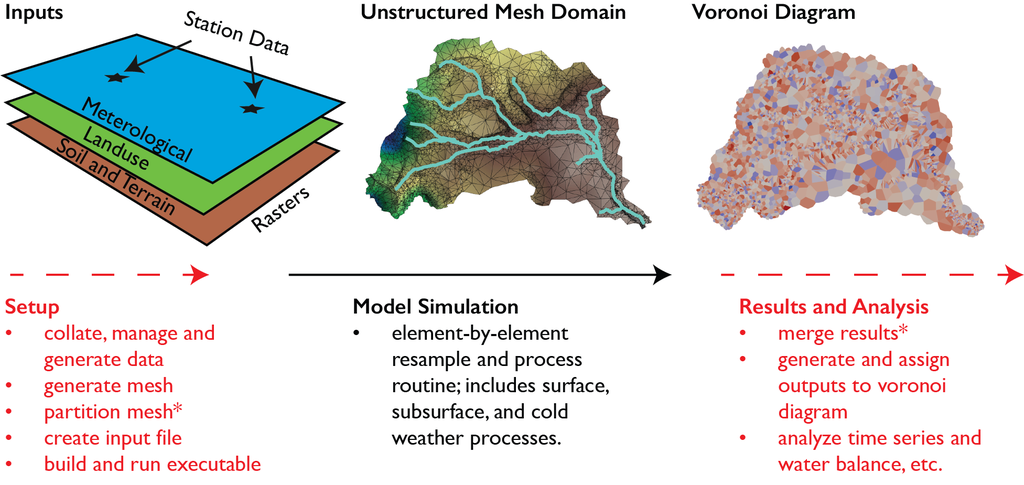

**Figure 1.** A tRIBS workflow consists of three main steps: (1) Collate and generate model inputs. (2) Run the model simulation(s). (3) Review and analyze results. The first and last step (denoted by red text and dashed lines) are user intensive activities that challenge reproducibility and are often very time consuming. The asterisks denote steps required for the parallel operation of the model.

## pytRIBS Design

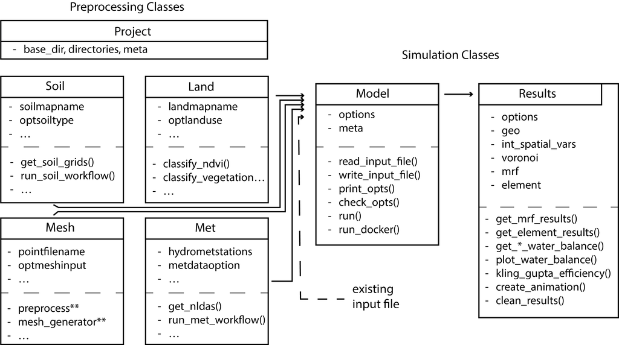

**Figure 2.** pytRIBS uses an object-oriented approach to capture the major components and steps required for setting up, simulating, and analyzing a tRIBS model. The preprocessing classes are intended to expedite the first step in setting up a tRIBS model, whereas the simulation classes provide users with tools to effectively run and analyze the model through a Python interface. The Project class is not directly linked to another class as it is limited to storing directory information and meta data. Only select attributes or methods are shown for each class, for a full list of attributes and methods see the associated documentation. *Water balance can be calculated for both the basin averaged condition or at individual nodes. **Mesh class relies on Preprocess and MeshGenerator classes accessed via these instances.

# Sandbox Start

pytRIBS has a set of workflows and general functions that can be used help creating a tRIBS model. The workflows are generally focused around downloading and processing commonly used datasets like the NLDAS-2 workflow for meteorological data. The general functions while helpful in any scenario are very helpful if datasets not built into pytRIBS are being used. A general model development workflow with pytRIBS is as follows:

1. Setup projection information and generate directory structure.
2. Watershed delineation.
3. Computational mesh development.
4. Soil data processing.
5. Meteorological data processing.
6. Land use data processing.
7. tRIBS input file generation.

To get started with the sandbox we have to first import the Python packages we will need like any other Python code.

## Imports

```python
# note you can install pytRIBS via pip; see: https://pypi.org/project/pytRIBS/
from pytRIBS.classes import *
```

```python
# if you have installed pytRIBS, the following libraries should already be in your environment
import os, sys, shutil
import geopandas as gpd
import matplotlib.pyplot as plt
import matplotlib.dates as mdates
import numpy as np
from shapely.ops import unary_union
from matplotlib.lines import Line2D
from matplotlib.patches import Patch
import matplotlib.ticker as mticker
import matplotlib.colors as mcolors
```

## Project Class: Setup Model Information

```python
name ='SMF'
epsg = 26912
proj = Project(os.getcwd(),name,epsg) # Create an instance of a Project Class
```

The output below is the folder directory structure that pytRIBS generates where the tRIBS model data is stored.

```python
proj.directories
```

```
{'model': 'data/model',
 'preprocessing': 'data/preprocessing',
 'results': 'results',
 'spinup': 'results/spinup',
 'restart': 'restart',
 'soil': 'data/model/soil',
 'land': 'data/model/land',
 'met_precip': 'data/model/met/precip',
 'met_meteor': 'data/model/met/meteor',
 'mesh': 'data/model/mesh'}
```

```python
proj.meta
```

```
{'Name': 'SMF', 'Scenario': None, 'EPSG': 26912}
```

The code below code copies in the needed pre-processed data sets and sets file paths to required data.

```python
# Set the file path to our DEM
dem = '../init_data/USGS_1m_clip.tif'

# Copy over our pre-generated Soil and Land Use ID rasters into our project directories
landuse_ras = '../init_data/LandUse.asc'
shutil.copy(landuse_ras, proj.directories['land'])
landuse_ras = f"{proj.directories['land']}/{os.path.basename(landuse_ras)}"

soil_ras = '../init_data/ADOT_SoilTypes.asc'
shutil.copy(soil_ras, proj.directories['soil'])
soil_ras = f"{proj.directories['soil']}/{os.path.basename(soil_ras)}"
```

## Mesh Class: Process DEM and Generate Mesh

### Preprocessing

Here initiate the class with arguments for the Preprocessing and MeshGeneration component classes.

Before we make a mesh we need to delineate the watershed and to do that we use the code below to define some of the information required.

```python
# Preprocessing Arguments
verbose_mode=False# suppresses whitebox output

# UTM coordinates for outlet/pour point
x = 394456
y = 3686772

snap_dis = 100 # allowable distance in m for snapping outlet points to stream network

# This area threshold for determining streams for watershed delineation
# Lets initially try 0.02 sqkm (2e4 m^2), this value is important because it determines the number of streams in tRIBS mesh
threshold_area = 2e4 # area in m^2 for determining stream network

# tuple of preprocessing arguments to be passed into the the mesh class
preprocess_args = ([x,y],snap_dis, threshold_area, dem, verbose_mode,proj.meta,proj.directories['preprocessing'])
```

```python
# Mesh Generation Arguments
# output directory can be specified in Preproceesing, but if not provided preprocessing is the default directory
output_dir = proj.directories['preprocessing']

path_to_raster = f'{output_dir}/{name}_clipped_ext.tif' # these are default outputs but can be further modified. See documentation.
path_to_watershed = f'{output_dir}/{name}_boundary.shp'
path_to_stream_network = f'{output_dir}/{name}_stream.shp'
path_to_outlet = f'{output_dir}/{name}_outlet.shp'
maxlevel= None # This can be set to none, if so the maximum level possible will be used.

mesh_generation_args = (path_to_raster, path_to_watershed, path_to_stream_network, path_to_outlet, maxlevel)
```

The code below executes the watershed delineation and saves all of the results to the filepaths listed above.

```python
tmesh = Mesh(preprocess_args=preprocess_args, generate_mesh_args=mesh_generation_args,meta=proj.meta,mesh_dir=proj.directories['mesh'])
```

Now, we have created all the files necessary for generating a mesh. Below we provide a visualization of these data. Note you could read this data in independently then plot it, but they are all ready assigned to `tmesh.mesh_generator` or alternatively can be used from the MeshGeneration class.

#### Example Figure 1: Preprocessing products produced by pytRIBS

```
Plotting with elevation limits: 395.8m to 728.8m
```

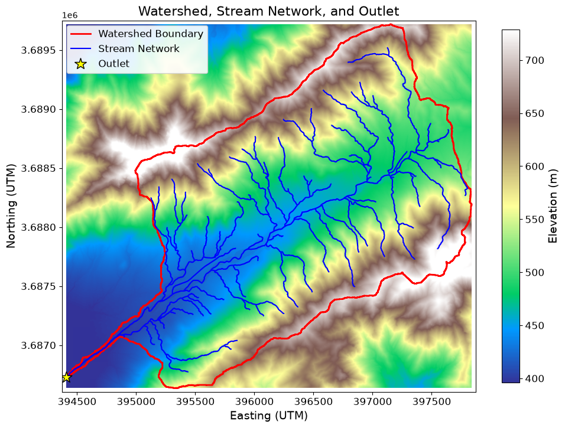

```python
dem_data = tmesh.mesh_generator.data
valid_data = dem_data[dem_data > -500]
vmin, vmax = np.percentile(valid_data, [2, 98])
print(f"Plotting with elevation limits: {vmin:.1f}m to {vmax:.1f}m")

# Create the Plot
fig, ax = plt.subplots(figsize=(10, 8))

extent = tmesh.mesh_generator.get_extent()

# Display the image with manual limits (vmin/vmax)
img = ax.imshow(
    dem_data,
    extent=extent,
    cmap='terrain',
    vmin=vmin,
    vmax=vmax
)

# Add colorbar
cbar = fig.colorbar(img, ax=ax, orientation='vertical', shrink=0.8)
cbar.set_label('Elevation (m)', fontsize=14)
cbar.ax.tick_params(labelsize=12)

# Plot watershed boundary (using Geopandas .plot)
tmesh.mesh_generator.watershed.plot(
    ax=ax,
    facecolor='none',
    edgecolor='red',
    linewidth=2,
    zorder=2 # draws on top of raster
)

# Plot stream network
tmesh.mesh_generator.stream_network.plot(
    ax=ax,
    linewidth=1.5,
    color='blue', # Rivers are usually blue!
    zorder=2
)

# Plot outlet
tmesh.mesh_generator.outlet.plot(
    ax=ax,
    color='yellow',
    marker='*',
    markersize=200, # Made it a bit bigger to see
    edgecolor='black',
    zorder=3
)

# Set axis labels and title
ax.set_xlabel('Easting (UTM)', fontsize=14)
ax.set_ylabel('Northing (UTM)', fontsize=14)
ax.set_title('Watershed, Stream Network, and Outlet', fontsize=16)
ax.tick_params(axis='both', which='major', labelsize=12)

# Create manual legend
legend_elements = [
    Line2D([0], [0], color='red', lw=2, label='Watershed Boundary'),
    Line2D([0], [0], color='blue', lw=1.5, label='Stream Network'),
    Line2D([0], [0], color='yellow', marker='*', markeredgecolor='black',
           markersize=15, linestyle='None', label='Outlet')
]

ax.legend(handles=legend_elements, loc='upper left', fontsize=12, framealpha=0.9)

# Add a buffer to zoom out slightly
# Get the bounding box coordinates of the watershed vector
minx, miny, maxx, maxy = tmesh.mesh_generator.watershed.total_bounds

# Calculate the width and height of the watershed
width = maxx - minx
height = maxy - miny

# Define a buffer percentage (e.g., 10% on each side)
buffer_pct = 0.01

# Apply the new limits with the buffer
ax.set_xlim(minx - (width * buffer_pct), maxx + (width * buffer_pct))
ax.set_ylim(miny - (height * buffer_pct), maxy + (height * buffer_pct))

plt.tight_layout()
plt.show()
```

### Mesh Generation

With the data from previous steps we can generate a locally refined mesh rapidly and easily using multiple methods combined into the same workflow.

1. Harr wavelet transform: this piece of the workflow is a method applied to the DEM to select significant points. Significance meaning how important is that location in describing the terrain.
2. Planar Straight Line Graph (PSLG). Using a open-source python tools we can generate a TIN mesh directly using our watershed boundary and streamlines as breaklines, embedding them into the mesh. Here we can also specify a number of constraints on the mesh generation like: what is the minimum interior angle allowed in the mesh?

Below is an example for executing the workflow. The parameters set produce a usable mesh but they can also be modified (to improve detail,reduce computational time, or experimentation). Another component of the mesh generation lies in the delineation step above with the stream network area threshold. This can be changed to add or reduce the number of streams which will embedded put into the mesh.

```python
# This parameter is a important piece of the mesh generation in pytRIBS.
# It controls how many points will be classified as significant thus kept versus in-significant points that don't need to be included in the mesh.
# Lower values means more points kept (denser mesh). Range from 0 to 1 (lower = denser).
threshold = 0.2
```

Mesh parameters

`threshold` controls initial interior-point density. After those points are created they are fed into triangulation algorithm to make the TIN mesh. The variables below are some of the constraint we can supply to the triangulation algorithm.

```python
boundary_buffer_dist = 40.0   # meters: watershed buffered outward to the no-flow boundary
boundary_spacing     = 70.0   # meters: node spacing on the boundary ring
stream_point_spacing = 40.0   # meters: node spacing along streams
stream_clear_radius  = 2.0   # meters: interior points this close to a stream are removed
quality_opts         = 'q15a15000'   # Triangle quality: q = min interior angle of triangle (degrees), a = max area (square meters)
```

Build the mesh

Writes the mesh created above into a set of 4 files: `{name}_mesh.nodes/.edges/.tri/.z` into `proj.directories['mesh']`. tRIBS reads these 4 files at the start of the simulation. The `diagnostics=True` option below writes inspection shapefiles (triangles, points, etc) for QA into the preprocessing folder.

After the code block below is ran a large printout below will be generated giving more details about the mesh created.

```python
tmesh.build_mesh(
    method='pslg',
    threshold=threshold,
    boundary_buffer_dist=boundary_buffer_dist,
    boundary_spacing=boundary_spacing,
    stream_point_spacing=stream_point_spacing,
    stream_clearance_radius=stream_clear_radius,
    mesh_quality_opts=quality_opts,
    diagnostics=True,                             # Set to true this write shapfiles of the TIN mesh
    separate_parallel_streams=True,               # With true a second pass is ran, essentially the TIN mesh is checked to remove potential issue then created again
)
```

```
Step 1: Generating buffered boundary from watershed shapefile...
  169 boundary nodes at ~70.0m spacing (buffer=40.0m)

Step 2: Building stream network...
  Stream outlet: (394406.00, 3686729.00)
  Outlet boundary node: idx=168 (394385.99, 3686694.42)
  996 stream nodes from 37.20 km at ~40.0m spacing

  Stream spacing guidance (your setting: 40.0m):
    DEM resolution       : 1.0m  ← minimum meaningful spacing
    Mean interior spacing: 43.6m  ← suggested maximum
    Suggested range      : 1.0m – 43.6m
    Longest flow path    : 5.87km (from assembled breakline)

Step 3: Preparing interior points...
  Removing 17 interior points within 5.0m of another.
  Applying 2.0m stream clearance zone...
  Removing 59 interior points inside clearance zone.
  220 inner boundary nodes at ~70.0m spacing

Step 4-6: Combining points, defining constraints, and triangulating...

Step 6: Triangulating...
  Pass 1: inserting 349 separator node(s) and re-triangulating.

Step 6: Triangulating...
  Pass 2: inserting 1 separator node(s) and re-triangulating.

Step 6: Triangulating...
  Premature stream merges resolved after 2 pass(es).

Step 7: Assigning elevations to mesh vertices...
  - Reading DEM: data/preprocessing/SMF_clipped_ext.tif
  - Filled 20 nodata elevation(s) from the nearest valid sample.
  - Sampled 2623 points.

Step 7b: Enforcing monotonic descent along stream network...
  Stream elevations already monotonically decreasing — no adjustments needed.

Step 8: Assigning node codes...
  Final codes — 0(Interior):1457  1(Boundary):168  2(Outlet):1  3(Stream):997

--- Preparing to write tRIBS mesh files ---

--- All tRIBS mesh files have been generated successfully. ---

--- Writing diagnostic shapefiles to data/preprocessing/SMF_mesh_*.shp ---
  Wrote 5075 triangles, 2623 nodes, 7697 edges.
```

```
<pytRIBS.mesh.mesh.MeshFromPSLG at 0x123270c20>
```

## Soil Class: Obtain and Generate tRIBS Soil Parameters

There are two methods to provide tRIBS soil parameters: a soil ID map and table or gridded parameter rasters. For SMF since we have the ADOT soil data as polygons we will use the simpler method, a soil ID map with a lookup table. Note pytRIBS has functionality to download gridded soil datasets that are publicly available but not used in this exercise.

```python
soil = Soil(meta=proj.meta)
```

Another component of the soil class is the initial ground water table and depth to bedrock.

Bedrock data can be quite difficult to find but it is becoming more available from Digital Soil Mapping (DSM) products. For this model we will apply the [SOLUS](https://www.nrcs.usda.gov/resources/data-and-reports/soil-landscapes-of-the-united-states-solus) dataset which has already been pre-processed for use here. Due to the shallow soils here and the dry conditions we are assuming that the initial groundwater table is essentially at the bedrock. To do that we multiplied our depth to bedrock raster by 95% i.e. if the depth to bedrock is 1m then the initial groundwater depth is 0.05m above the bedrock.

All we need to do is copy over the data into our model directory.

```python
# Depth to Bedrock
shutil.copy('../init_data/SOLUS_Bedrock_m.asc', proj.directories['soil'])
soil.bedrockfile['value'] = f"{proj.directories['soil']}/SOLUS_Bedrock_m.asc"

# Initial Groundwater Table
shutil.copy('../init_data/InitGW_95pct_mm.asc', proj.directories['soil'])
soil.gwaterfile['value'] = f"{proj.directories['soil']}/InitGW_95pct_mm.asc"
```

Now that the soil class is created we can tell pytRIBS that we already have the soil data. Instead of using the tools built-in to pytRIBs to download and prepare soil data.

```python
# Point pytRIBS at the soil ID map and where the new soil table will be written
soil.soilmapname['value'] = soil_ras
soil.soiltablename['value'] = f"{proj.directories['soil']}/soils.sdt"
```

```python
# Texture labels per class ID (from the ADOT Soil dataset)
# This looks complicated but really we are just assigning soil ID number a specific name from the ADOT dataset
soil_textures = {
      '1': 'RS', '2': 'CO', '3': 'CeD', '4': 'EbD', '5': 'Cb',
}
soil_map = InOut.read_ascii(soil.soilmapname['value'])

# Build an empty table straight from the soil map's class IDs
soil_table = soil.create_soil_table_from_map(textures=soil_textures)
```

Now that we have a blank soil table we can fill it up with the parameter values from the ADOT dataset.

```python
# Lets define the soil parameters. Some are parameters are specific to each soil class, some will be static across all classes
# More information here: https://tribshms.readthedocs.io/en/latest/man/Model_Parameters_Forcings.html

# Define Hydraulic Parameters for Specific Soil Classes
# Here we map the specific soil IDs found in the ADOT dataset (MUSYM) to physical hydraulic parameters.
# In a research setting, these might be derived from pedotransfer functions (like Rosetta) or field tests.
# For this exercise, we are using the values from the ADOT data as a starting point.

# Parameters:
# - Ks: Saturated hydraulic conductivity (mm/hr)
    # This is an important calibration parameter
# - thetaS: Saturation soil moisture content (porosity) (-)
# - thetaR: Residual soil moisture content (-)
# - m: Pore size distribution index (Lambda) (-)
# - PsiB: Air entry/Bubbling pressure (mm)
# - f: Conductivity decay parameter (1/mm) - Controls how fast Ksat decreases with depth
    # This is an important calibration parameter
# - n: Porosity (-)

# Define a dictionary to map your ADOT Soil IDs to parameters.
soil_param_lookup = {
    # Soil: RS
    '1': {
        'Ks': 3.6,      # From ADOT dataset, KEY calibration parameter
        'thetaS': 0.40,  # From ADOT dataset
        'thetaR': 0.06,  # Initial guess we are using 0.5*wilting point
        'm': 0.38,       # Value selected from Rawls et al 1984.
        'PsiB': -390,    # From ADOT dataset
        'f': 0.001,       # Assume initial value, KEY calibration parameter
        'n': 0.40        # Initial guess we are using this is equal to thetaS
    },
    # Soil: CO
    '2': {'Ks': 2.8,  'thetaS': 0.40, 'thetaR': 0.05, 'm': 0.25, 'PsiB': -401, 'f': 0.001, 'n': 0.40},
    # Soil: CeD
    '3': {'Ks': 6.6,  'thetaS': 0.40, 'thetaR': 0.05, 'm': 0.25, 'PsiB': -183, 'f': 0.001, 'n': 0.40},
    # Soil: EbD
    '4': {'Ks': 1.0,  'thetaS': 0.42, 'thetaR': 0.10, 'm': 0.20, 'PsiB': -450, 'f': 0.001, 'n': 0.42},
    # Soil: Cb
    '5': {'Ks': 17.3, 'thetaS': 0.39, 'thetaR': 0.03, 'm': 0.18, 'PsiB': -117, 'f': 0.001, 'n': 0.39},
}

# Now that we defined our parameter values above lets populate the soil data table with thos values
for cls in soil_table:
    # Constant parameter values for all soil classes
    cls.update({'As': 1, 'Au': 1, 'ks': 0.7, 'Cs': 1.4e6})
    cls.update(soil_param_lookup[cls['ID']])
    print(f"Assigned parameters for Soil ID {cls['ID']} ({cls['Texture']})")

# Write the populated soil table
soil.write_soil_table(soil_table, soil.soiltablename['value'], textures=True)
```

```
Assigned parameters for Soil ID 1 (RS)
Assigned parameters for Soil ID 2 (CO)
Assigned parameters for Soil ID 3 (CeD)
Assigned parameters for Soil ID 4 (EbD)
Assigned parameters for Soil ID 5 (Cb)
Soil texture reference written to data/model/soil/soils_textures.csv. This file is for user reference only and is not read by tRIBS.
```

Now that we have the soil table lets tell pytRIBS that in the main input file we will be using soil option 0 that corresponds to using the soil table

```python
soil.optsoiltype['value'] = 0
```

#### Example Figure 3: Example soil classification map generated from pytRIBS Soil Class

```
Found 5 unique soil classes: [1 2 3 4 5]
```

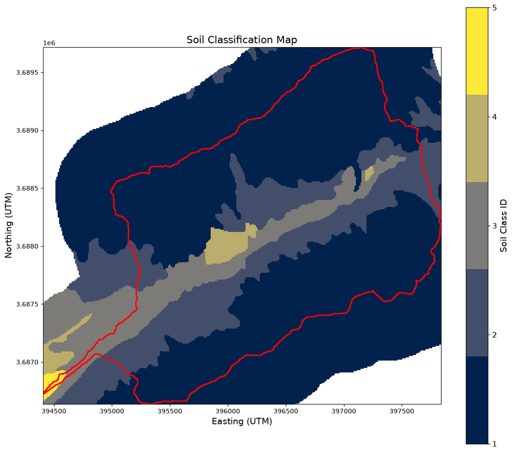

```python
import matplotlib.colors as colors
import matplotlib.ticker as mticker
import numpy as np

data = soil_map['data']
transform = soil_map['profile']['transform']

# Calculate Extent (Standard GeoTransform logic)
x_min = transform[2]
x_max = x_min + soil_map['profile']['width'] * transform[0]
y_max = transform[5]
y_min = y_max + soil_map['profile']['height'] * transform[4]
extent = [x_min, x_max, y_min, y_max]

# Mask  Data
masked_data = np.ma.masked_less(data, 0)

# Find unique soil classes for the legend
unique_classes = np.unique(masked_data.compressed())
num_classes = len(unique_classes)

print(f"Found {num_classes} unique soil classes: {unique_classes}")

# Create Discrete Colormap
cmap = plt.get_cmap('cividis', num_classes)
norm = colors.BoundaryNorm(np.arange(len(unique_classes) + 1), cmap.N)

# Plotting
fig, ax = plt.subplots(figsize=(12, 10))
img = ax.imshow(
    masked_data,
    extent=extent,
    cmap=cmap,
    interpolation='nearest' # Prevents blurring between classes
)

# 6. Watershed Boundary
tmesh.mesh_generator.watershed.plot(
    ax=ax,
    facecolor='none',
    edgecolor='red',
    linewidth=2,
    label='Watershed Boundary'
)

# 7. Custom Colorbar for Categorical Data
# We tell the colorbar to only show ticks at the center of each discrete color
cbar = plt.colorbar(img, ax=ax, ticks=unique_classes)
cbar.set_label('Soil Class ID', fontsize=14)
cbar.ax.tick_params(labelsize=12)

# Set the limits of the image to the watershed bounds
bounds = tmesh.mesh_generator.watershed.total_bounds
ax.set_xlim([bounds[0], bounds[2]])
ax.set_ylim([bounds[1], bounds[3]])

# Labels
ax.set_xlabel('Easting (UTM)', fontsize=14)
ax.set_ylabel('Northing (UTM)', fontsize=14)
ax.set_title(f'Soil Classification Map', fontsize=16)

plt.tight_layout()
plt.show()
```

## Met Class: Assign Meteorological Forcing Data

Meteorological forcing for the tRIBS model can be supplied either as point-based station data or as raster data. Managing these data manually can be time-consuming and susceptible to errors. To simplify this process, the Met class allows users to specify the filepaths to already generated forcings files or efficiently obtain meteorological forcing data from the North American Land Data Assimilation System (NLDAS) for a specified location and time period.

For this notebook forcing data has already been prepared so we will not be using the NLDAS workflow. First we need to tell pytRIBS the files paths where our pre-processed forcing will be located:

```python
met = Met(meta=proj.meta) # Initializing the pytRIBS Met Class
met.hydrometstations['value'] = "../init_data/met/Master_Met.sdf" # File path to where station data file will live
met.gaugestations['value'] = "../init_data/met/Master_Precip.sdf" # File path to where station data file will live
```

Meteorological forcings for SMF have already been generated using the `Generate_Met_Forcing` notebook. If you want to change the simulation's length or time period, rerun that notebook to regenerate the forcing files.

More details on the required tRIBS forcing files are located here: [Model Forcings](https://tribshms.readthedocs.io/en/latest/man/Model_Forcings.html#model-forcings)